# Finding Themes in Indonesian Twitter with LSA and LDA

### 1 August 2018

## I. Definition

### Project Overview

On 9 July, 2014, millions of people accross the world's fourth most-populous country went to the polls in a presidential contest widely portrayed as a choice between Indonesia's authoritarian past and a more-democratic and populist future. After 13 days, Indonesia's Election Commission declared Jakarta Governor Joko Widodo, lovingly known as Jokowi, the election's winner against former General Prabowo Subianto in a [53% to 47% split](https://www.bbc.com/news/world-asia-28415536).

In 2014 as today, Indonesia has consistently ranked among the [top 5 countries represented on Twitter](https://www.reuters.com/article/us-twitter-indonesia-idUSKCN0VK2LP), offering a wealth of potential natural language data for analysis. In this project, I'll explore latent topics within a twitter corpus to better understand the Indonesian public's (or rather the young, urban public's) views surrounding the election, as well as the volume of tweets produced by topic.

### Problem Statement

The biggest problem with analyzing text data is that it's inherently unstructured. Twitter users misspell words, contract words, repeat letters for emphasis, and all of this is just on the originator's end. The tweets also end up with widely variant lengths and different gramatical structures, making language especially complicated for doing comparative mathematical operations (data science).

For problems like this, so-called bag-of-words models, where a computer makes a dictionary of every possible word and then counts the number of times each word appears in a given tweet, provide an easy way to standardize the data into a set format for representing each tweet. Bags-of-words also lend themselves to two widely-used algorithms for discovering topics within tweets and then grouping tweets by those topics: Latent Semantic Analysis (LSA) and Latent Dirichlet Allocation (LDA). By running these algorithms against our tweets, we can find latent themes among tweeters, examining the main words in each theme to get a sense for which model better creates understandable groupings.

## II. Analysis

### Data Exploration

The [corpus of tweets](https://github.com/aliakbars/bilp) I use, collected during the 2014 Indonesian elections by GitHub user Ali Akbar S., was originally intended for sentiment analysis, and consists of rows of tweets in Indonesian paired with a 1, 0, or -1 depending on the perceived sentiment of the text. It's also limited to only 1,846 tweets, meaning the tweets' short lengths and limited number could adversely affect the algorithms' ability to find themes. Since we're not examining sentiment in this analysis, I chose to drop the final column, keeping only a vector, a "list" if you will, of individual tweets.

```python
# Load and visualize dataset
import pandas as pd
data = pd.read_csv('tweets.csv')
print(data.head())

#Find dataset size
print("\n{} tweets in dataset".format(len(data)))
```

```
                                           isi_tweet  sentimen
0  tidak setuju jokowi jadi cawapres capres jokow...         1
1  capres jokowi wacapres abraham samad gubernur ...         1
2  capres prabowo dan cawapres jokowi dan gubdki ...         1
3  jadi skenarionya gini 2014 biar prabowo jadi p...         1
4  sby mantan tni dan calon presiden prabowo subi...         1

1846 tweets in dataset
```

I was surprised to find some Tweets over 140 characters, the limit until 2017. But examining the first 5 of these Tweets didn't reveal anything unusual. Instead, I saw some regular problems with Twitter data, like Tweeters forgetting to type spaces between words, or users concatenating (sticking together) numbers and letters.

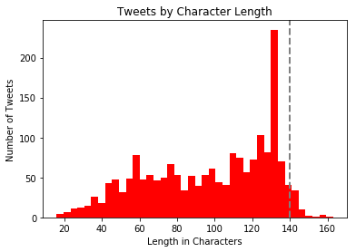

```python
import matplotlib.pyplot as plt
lengths = []
for i in data.isi_tweet:
    lengths.append(len(i))

plt.hist(lengths, bins = 40, facecolor='red')
plt.axvline(x=140, color='gray', linestyle='dashed', linewidth=2)
plt.title("Tweets by Character Length")
plt.xlabel("Length in Characters")
plt.ylabel("Number of Tweets")
plt.show()
```

```python
# Print first 10 tweets over 140 characters
countdown = 5
for i in data.isi_tweet:
    if len(i) >140:
        if countdown == 0:
            break
        print("----------\nTweet {}:".format(countdown))
        print(i)
        countdown -= 1
```

```
----------
Tweet 5:
jadi skenarionya gini 2014 biar prabowo jadi presiden jokowi tetepgubernur kalau jakarta berhasil tidak usah nunggu 2019 buat gantiin prabowo
----------
Tweet 4:
saat jadi meneg bumn dahlan iskan bisa sedikit ambil bagian dalam kep strategis pln saat jadi presiden jokowi bisa juga melakukan hal yang sama untuk jakarta
----------
Tweet 3:
capres arb banyak beriklan mengeluarkan kata2 yang membuai rakyat kemudian membuat statement elektabilitasnya naik jangan hnya segitunya bung
----------
Tweet 2:
sebel lihat capres aburizal bakrie tidak tahu kenapa dia ya nyalon atas dasar apa juga tidak ngrti mau ngurusin indonesia ngurusin lapindo saja tidak kelar2
----------
Tweet 1:
eneggg sangat saya lihat iklan capres arb di iklan ngomong a sok bijak bnr sebener a dia punya kaca tidak sii di rumahnya lapindoajablomkelar
```

### Algorithms and Techniques

English has long dominated the tech field, and most existing natural language processing (NLP) packages are created to augment English language data for analysis. Since the twitter data is in Indonesian, we have to get a little creative with our preprocessing:

To deal with punctuation, numbers, and numbers concatinated with words, I imported regular expressions, or RegEx,to drop everything but alphabetical characters. I imported an NLP package, Gensim, to easily build models, and NumPy to set a random seed for reproducable results. A package called [Sastrawi](https://github.com/sastrawi/sastrawi) converts Indonesian words to their root forms without prefixes or suffixes and lowercases them, and the CSV package allowed me to read in a separate list from Kaggle to remove the most common Indonesian words from the corpus (the first time I ran LDA, several topics included words like dan ("and") or di ("at")). I also added an index column to use later to identify specific tweets.

After parsing the tweets into a list of individual preprocessed words and using Gensim to create a bag-of-words, I ran my LSA model and two LDA models on the data to see which model produced the clearest and most-coherent topics. LSA is a simpler algorithm and is less computationally expensive to run, but LDA typically results in more sensible topics. LDA can be run either on the bag of words immediately, or after performing an algorithm called term frequency/inverse document frequency (Tf-idf) which amplified the differences between tweets. Post-Tf-idf LDA is an industry standard, but can result in propper nouns being overtrepresented, which might result in less-clear categorizations, depending on the corpus. Testing all three, first to discern general topics over the corpus, then to categorize a chosen tweet, then finally to categorize a fake tweet I will compose, should give me a good idea of which method works best in this instance.

```python
#import packages used
import csv
import re
import gensim
from gensim import corpora, models
#import nltk
#nltk.download('punkt')
#from nltk.tokenize import word_tokenize
import numpy as np
import Sastrawi
from Sastrawi.Stemmer.StemmerFactory import StemmerFactory

# set random seed for reproducable results
np.random.seed(45)
```

```python
#Add indexing for future gensim use
data_text = data[['isi_tweet']]
data_text['index'] = data_text.index
tweets = data_text
print(tweets.head())
```

```
                                           isi_tweet  index
0  tidak setuju jokowi jadi cawapres capres jokow...      0
1  capres jokowi wacapres abraham samad gubernur ...      1
2  capres prabowo dan cawapres jokowi dan gubdki ...      2
3  jadi skenarionya gini 2014 biar prabowo jadi p...      3
4  sby mantan tni dan calon presiden prabowo subi...      4
```

## III. Methodology

### Data Preprocessing

Sastrawi's stemmer worked impressively well against some highly-conjugated example sentences I entered in Indonesian, and had the additional benefit of lowercasing my words. The stop words list included various conjugations of common words, but since the list was not exhaustive, I removed stop words only after stemming and removing non-alphabetical characters.

```python
# Create Indonesian stemming function and test on conjugated sentences
factory = StemmerFactory()
indoStemmer = factory.create_stemmer()

def indoStem(text):
    stemmed = indoStemmer.stem(text)
    return stemmed

sentences = ["Mereka meniru-nirukannya", "Saya pembantu", "Dia dipanggil oleh wanita tercantik"]

for sentence in sentences:
    print("-----\nOriginal: {}".format(sentence))
    output = indoStem(sentence)
    print("\nStemmed: {}".format(output))
```

```
-----
Original: Mereka meniru-nirukannya

Stemmed: mereka tiru
-----
Original: Saya pembantu

Stemmed: saya bantu
-----
Original: Dia dipanggil oleh wanita tercantik

Stemmed: dia panggil oleh wanita cantik
```

```python
# Read Indonesian stopword CSV into Python and turn it into a list
stopwords_list = []
with open('stopwords.csv', 'r') as f:
    reader = csv.reader(f)
    stopwords_list = list(reader)
    flat_stoplist = [item for sublist in stopwords_list for item in sublist]

# Create function to preprocess each tweet by removing non-alphabetical characters, stemming words,
## and removing stopwords
def preprocess(text):
    result=[]
    text = re.sub("[^a-zA-Z]+", " ", text)
    stemmed = indoStem(text)
    for word in stemmed.split(' '):
        if word not in flat_stoplist:
            result.append(word)
    return result
```

```python
# Map preprocessing to isi_tweet column and print first 5 instances to check
processed_tweets = list(map(preprocess, tweets['isi_tweet']))
processed_tweets[:5]
```

```
[['tuju', 'jokowi', 'cawapres', 'capres', 'jokowi', 'harga', 'mati'],
 ['capres',
  'jokowi',
  'wacapres',
  'abraham',
  'samad',
  'gubernur',
  'ahok',
  'koruptor',
  'abissss'],
 ['capres',
  'prabowo',
  'cawapres',
  'jokowi',
  'gubdki',
  'ahok',
  'mantap',
  'presiden',
  'sby',
  'bubar',
  'fpi'],
 ['skenario',
  'gin',
  'biar',
  'prabowo',
  'presiden',
  'jokowi',
  'tetepgubernur',
  'jakarta',
  'hasil',
  'nunggu',
  'gantiin',
  'prabowo'],
 ['sby',
  'mantan',
  'tni',
  'calon',
  'presiden',
  'prabowo',
  'subianto',
  'mantan',
  'kopassus',
  'anggoto',
  'tni',
  'disiplin',
  'smw',
  'presiden']]
```

To run my models in Gensim, I needed to create a dictionary of the word in my corpus, and chose to remove words that appeared less than 40 times or in more than 30% of tweets. This removed words that could muddle underlying categories by being too common or rare. I also ran my Tf-idf algorithm at this point for later use in my model.

```python
dictionary = gensim.corpora.Dictionary(processed_tweets)
print(len(dictionary))
```

```
4117
```

```python
dictionary.filter_extremes(no_below = 40, no_above = 0.3)
print(len(dictionary))
```

```
50
```

```python
bow_corpus = [dictionary.doc2bow(twt) for twt in processed_tweets]
bow_corpus[15]
```

```
[(1, 1), (2, 1), (15, 2), (16, 1)]
```

```python
bow_tweet_14 = bow_corpus[15]
for i in range(len(bow_tweet_14)):
    print("Word {} (\"{}\") appears {} time.".format(bow_tweet_14[i][0],
                                                     dictionary[bow_tweet_14[i][0]],
                                                     bow_tweet_14[i][1]))
```

```
Word 1 ("ahok") appears 1 time.
Word 2 ("gubernur") appears 1 time.
Word 15 ("ya") appears 2 time.
Word 16 ("indonesia") appears 1 time.
```

```python
tfidf = models.TfidfModel(bow_corpus)
corpus_tfidf = tfidf[bow_corpus]
from pprint import pprint
for doc in corpus_tfidf:
    pprint(doc)
    break
```

```
[(0, 1.0)]
```

### Implementation and Refinement

I experiemented with a range of numbers of topics, and landed on 5 as a reasonable number on which to run my LSA, BOW LDA and Tf-idf LDA models. I also adjusted my parameters for filtering my Gensim dictionary to the final parameters of 40 <= total number of times a word is observed in the corpus <= 30% of the corpus from my original parameters of 15 <= total observations in the corpus <= 50% of the corpus, which on first glance seemed to give clearer topics.

```python
num_topics = 5
```

## IV. Results

### Model Evaluation and Validation

```python
lsa_model = gensim.models.LsiModel(corpus_tfidf,
                                   num_topics = num_topics,
                                   id2word=dictionary)
for idx, topic in lsa_model.print_topics(-1):
    print("Topic: {} \nWords: {}".format(idx, topic))
    print("\n")
```

```
Topic: 0
Words: 0.421*"megawati" + 0.395*"wakil" + 0.373*"mantan" + 0.354*"jusuf" + 0.354*"kalla" + 0.300*"jk" + 0.212*"prabowo" + 0.120*"nyata" + 0.119*"gubernur" + 0.110*"tokoh"


Topic: 1
Words: -0.897*"megawati" + 0.199*"jusuf" + 0.199*"kalla" + 0.184*"wakil" + 0.166*"jk" + 0.119*"prabowo" + 0.107*"mantan" + 0.070*"nyata" + 0.057*"bincang" + 0.057*"tokoh"


Topic: 2
Words: -0.904*"prabowo" + 0.151*"jusuf" + 0.149*"kalla" + 0.146*"mantan" + -0.145*"wiranto" + -0.114*"arb" + 0.107*"wakil" + -0.092*"indonesia" + -0.086*"cawapres" + -0.077*"calon"


Topic: 3
Words: -0.850*"dahlan" + -0.407*"iskan" + 0.155*"prabowo" + -0.133*"konvensi" + -0.077*"pilih" + -0.076*"maju" + -0.074*"arb" + 0.070*"mantan" + 0.070*"jusuf" + 0.068*"kalla"


Topic: 4
Words: 0.561*"arb" + 0.411*"hatta" + 0.340*"wiranto" + -0.240*"prabowo" + -0.187*"dahlan" + 0.179*"cawapres" + 0.168*"ketua" + 0.162*"pan" + 0.162*"buka" + 0.150*"evaluasi"
```

LDA with a bag of words seemed better, with topics such as “Kalla”, “Leader(ship)”, “Governor (Jokowi)”, “Real”, and “Popular” (Topic zero: Jokowi), “Dahlan”, “Prabowo”, “Wiranto”, “Fill in”, “Yes”, “Support”, “Ahok”, and “Governor” (Topic one: Famous endorsements of Jokowi against Prabowo), “Kalla”, “Aburizal Bakrie”, “Prabowo” “Tri Rismaharini”, and “Mahfud MD” (Topic 2: Famous Endorsements of Prabowo against the Jokowi-Kalla ticket, or in Rismaharini’s case, a fake endorsement), “convention”, “PDI-P party”, “Golkar party”, “Mahfud MD”, “survey”, “People’s/public”, “win” (Topic three: polling and party comparison), and “Megawati”, “PAN”, “Presidential candidacy”, and “Hatta Radjasa” (Topic four: Prabowo). The topics also had a nice symmetry, with one topic per major candidate, one topic of famous supporters of each candidacy, and a topic on polling and party comparison.

```python
lda_model = gensim.models.LdaMulticore(bow_corpus,
                                       num_topics = num_topics,
                                       id2word = dictionary,
                                       passes = 2,
                                       workers = 4)
for idx, topic in lda_model.print_topics(-1):
    print("Topic: {} \nWords: {}".format(idx, topic))
    print("\n")
```

```
Topic: 0
Words: 0.123*"kalla" + 0.118*"jusuf" + 0.116*"wakil" + 0.110*"mantan" + 0.041*"nyata" + 0.040*"jk" + 0.040*"tokoh" + 0.035*"gubernur" + 0.035*"sosok" + 0.035*"populer"


Topic: 1
Words: 0.153*"dahlan" + 0.132*"prabowo" + 0.088*"wiranto" + 0.083*"iskan" + 0.057*"indonesia" + 0.055*"ya" + 0.047*"cawapres" + 0.037*"ahok" + 0.033*"gubernur" + 0.025*"dukung"


Topic: 2
Words: 0.159*"jk" + 0.142*"arb" + 0.080*"wakil" + 0.065*"prabowo" + 0.053*"pilih" + 0.051*"calon" + 0.047*"risma" + 0.034*"mantan" + 0.031*"mahfud" + 0.027*"wapres"


Topic: 3
Words: 0.083*"konvensi" + 0.072*"pdip" + 0.068*"pilih" + 0.064*"partai" + 0.060*"golkar" + 0.055*"mahfud" + 0.049*"survey" + 0.045*"menang" + 0.041*"rakyat" + 0.041*"md"


Topic: 4
Words: 0.150*"hatta" + 0.119*"megawati" + 0.072*"ketua" + 0.066*"buka" + 0.065*"pan" + 0.060*"pencapresan" + 0.060*"evaluasi" + 0.059*"radjasa" + 0.047*"cawapres" + 0.039*"calon"
```

LDA with Tf-idf gave interesting topics such as “Dahlan”, “PDI-P”, “Forward”, “Support”, “Mega(wati)”, “Governor”, “Kalla” (Topic zero: Jokowi), “Hatta”, “Megawati”, “Party”, “Kalla”, “Vice President”, “PAN” and “Evaluation” (Topic one: Vice Presidents), “Jakarta”, “Dahlan”, “Convention”, “Vice President”, “Megawati”, “Yudhoyono”, “Mahfud MD” (Topic two: national political players), “Aburizal Bakrie”, “Candidate”, “Ad”, “Survey”, “Tri Rismaharini”, “Yudhoyono”, “Prabowo”, “Vice Presidential Candidate”, and “Kalla” (Topic three: unclear, possibly political advertisements and polling), and “Prabowo”, “Vice”, “Kalla”, “Wiranto”, “Megawati”, “People”, and “Indonesia” (Topic five: unclear, more famous political players). However, the topics seemed less clearly-defined than LDA with the bag of words.

```python
lda_model_tfidf = gensim.models.LdaMulticore(corpus_tfidf,
                                             num_topics = num_topics,
                                             id2word = dictionary,
                                             passes = 2,
                                             workers=4)

for idx, topic in lda_model_tfidf.print_topics(-1):
    print("Topic: {} \nWords: {}".format(idx, topic))
    print("\n")
```

```
Topic: 0
Words: 0.162*"dahlan" + 0.080*"pdip" + 0.076*"pilih" + 0.071*"iskan" + 0.063*"maju" + 0.063*"dukung" + 0.057*"mega" + 0.056*"gubernur" + 0.046*"jk" + 0.043*"pasang"


Topic: 1
Words: 0.125*"hatta" + 0.124*"megawati" + 0.083*"partai" + 0.071*"jk" + 0.053*"ya" + 0.050*"ketua" + 0.047*"cawapres" + 0.046*"buka" + 0.043*"pan" + 0.041*"evaluasi"


Topic: 2
Words: 0.117*"jakarta" + 0.087*"dahlan" + 0.085*"orang" + 0.069*"konvensi" + 0.065*"wapres" + 0.051*"iskan" + 0.051*"megawati" + 0.036*"sby" + 0.031*"md" + 0.030*"mahfud"


Topic: 3
Words: 0.182*"arb" + 0.117*"calon" + 0.086*"iklan" + 0.067*"survey" + 0.046*"risma" + 0.041*"sby" + 0.039*"prabowo" + 0.038*"cawapres" + 0.038*"indonesia" + 0.035*"jk"


Topic: 4
Words: 0.122*"prabowo" + 0.079*"wakil" + 0.071*"mantan" + 0.067*"kalla" + 0.065*"wiranto" + 0.065*"jusuf" + 0.051*"megawati" + 0.043*"rakyat" + 0.032*"jk" + 0.031*"indonesia"
```

### Justification

For this particular corpus, and perhaps this is related to the small total number of tweets and the limited words in each tweet, LDA performed better when not weighted with Tf-idf, so that is the model and topic grouping I chose to proceed with.

### Spot Checking

```python
document_num = 30
print(data.iloc[document_num, 0])

print(processed_tweets[document_num])
```

```
kalau jadi presiden jokowi tetep jadi gubernur jakarta tidak
['presiden', 'jokowi', 'tetep', 'gubernur', 'jakarta']
```

```python
for index, score in sorted(lda_model[bow_corpus[document_num]], key=lambda tup: -1*tup[1]):
    print("\nScore: {}\t \nTopic: {}".format(score, lda_model.print_topic(index, 10)))
```

```
Score: 0.729947566986084
Topic: 0.150*"hatta" + 0.119*"megawati" + 0.072*"ketua" + 0.066*"buka" + 0.065*"pan" + 0.060*"pencapresan" + 0.060*"evaluasi" + 0.059*"radjasa" + 0.047*"cawapres" + 0.039*"calon"

Score: 0.06830424070358276
Topic: 0.123*"kalla" + 0.118*"jusuf" + 0.116*"wakil" + 0.110*"mantan" + 0.041*"nyata" + 0.040*"jk" + 0.040*"tokoh" + 0.035*"gubernur" + 0.035*"sosok" + 0.035*"populer"

Score: 0.06825393438339233
Topic: 0.153*"dahlan" + 0.132*"prabowo" + 0.088*"wiranto" + 0.083*"iskan" + 0.057*"indonesia" + 0.055*"ya" + 0.047*"cawapres" + 0.037*"ahok" + 0.033*"gubernur" + 0.025*"dukung"

Score: 0.06682510673999786
Topic: 0.159*"jk" + 0.142*"arb" + 0.080*"wakil" + 0.065*"prabowo" + 0.053*"pilih" + 0.051*"calon" + 0.047*"risma" + 0.034*"mantan" + 0.031*"mahfud" + 0.027*"wapres"

Score: 0.06666915863752365
Topic: 0.083*"konvensi" + 0.072*"pdip" + 0.068*"pilih" + 0.064*"partai" + 0.060*"golkar" + 0.055*"mahfud" + 0.049*"survey" + 0.045*"menang" + 0.041*"rakyat" + 0.041*"md"
```

```python
fake_tweet = "Saya mendukung JK dan Kalla! PDI-P selamanya!"
bow_vector = dictionary.doc2bow(preprocess(fake_tweet))

print("LDA with BOW Model:")
for index, score in sorted(lda_model[bow_vector], key=lambda tup: -1*tup[1]):
    print("\nScore: {}\t \nTopic: {}".format(score, lda_model.print_topic(index, 10)))
```

```
LDA with BOW Model:

Score: 0.7960905432701111
Topic: 0.123*"kalla" + 0.118*"jusuf" + 0.116*"wakil" + 0.110*"mantan" + 0.041*"nyata" + 0.040*"jk" + 0.040*"tokoh" + 0.035*"gubernur" + 0.035*"sosok" + 0.035*"populer"

Score: 0.05283946916460991
Topic: 0.159*"jk" + 0.142*"arb" + 0.080*"wakil" + 0.065*"prabowo" + 0.053*"pilih" + 0.051*"calon" + 0.047*"risma" + 0.034*"mantan" + 0.031*"mahfud" + 0.027*"wapres"

Score: 0.050536468625068665
Topic: 0.153*"dahlan" + 0.132*"prabowo" + 0.088*"wiranto" + 0.083*"iskan" + 0.057*"indonesia" + 0.055*"ya" + 0.047*"cawapres" + 0.037*"ahok" + 0.033*"gubernur" + 0.025*"dukung"

Score: 0.05044544115662575
Topic: 0.083*"konvensi" + 0.072*"pdip" + 0.068*"pilih" + 0.064*"partai" + 0.060*"golkar" + 0.055*"mahfud" + 0.049*"survey" + 0.045*"menang" + 0.041*"rakyat" + 0.041*"md"

Score: 0.05008801072835922
Topic: 0.150*"hatta" + 0.119*"megawati" + 0.072*"ketua" + 0.066*"buka" + 0.065*"pan" + 0.060*"pencapresan" + 0.060*"evaluasi" + 0.059*"radjasa" + 0.047*"cawapres" + 0.039*"calon"
```

## V. Conclusion

### Improvement

To really shine, these models should be applied to a much larger corpus. The corpus should also be cleaned of characters repeated three or more times as well as English words, which I observed at times within the corpus. With these conditions met, the models would be more robust and better represent the Indonesian twitter population during the 2014 Indonesian election. A more complete corpus could also enable me to map the sizes of each topic cluster more meaningfully to answer questions such as whether Jokowi or Prabowo seemed to generate more tweets, or how many tweets seem to have been about endorsements or supporters rather than focusing on the actual candidates. There’s lots of room to expand this basic code framework and hopefully improve insights around Indonesian political twitter for the 2019 election.